# R Notebook

3. The report 3.1 Structure and length The report contains the following sections, in this order:
4. Title
5. Authors (the author names are stated below the title)
6. Abstract
7. Introduction
8. Model & Methods
9. Results
10. Discussion
11. References The report contains no more than 3000 words of main text (i.e., excluding code)

# Model question and assumptions

Our model explores how migration from a source beach affects the populations of usual and adapted turtles on a beach affected by warming. We compare the two turtle types over generations and investigate how different migration rates change the final population sizes.

The model represents two types:

Type a (immigrating turtles from a cool beach): their expected offspring number is reduced by decay_rate.

Type A (adapted turtles to the new habitat warming beach): their expected growth is affected by warming and by the relative advantage specified by sel_coeff.

New A turtles can arise through mutation from a. In the current code, migrants from the source/cool beach are type a turtles, not adapted type A turtles. The source population is treated as constant.

This is a simplified model. decay_rate represents the negative effect of warming rather than simulating ocean temperature directly. Migration is represented by a rate of immigration, not by explicitly modelling two different routes or route-specific mortality.

# Parameters, initial conditions and variables

[output not shown]

# Simulate One Generation

The first function calculates what happens over one generation. The order of events in our code is:

1. Generate offspring for both types.
2. If the total offspring exceeds carrying capacity, reduce the offspring numbers to the limit.
3. Generate mutations from type `a` to type `A` among the `a` offspring.
4. Generate immigrants of type `a` from the source beach.
5. Calculate the population sizes `a` and `A` for the next generation.

```r
# FUNCTION 1: SIMULATE ONE GENERATION

# The model includes two turtle types:
# a = usual turtles, which are affected by warming
# A = adapted turtles, which have a relative growth advantage

simulate_one_gen <- function(N_a, N_A, decay_rate, sel_coeff, mut_rate, mig_rate, N_source_a, carrying_capacity = 1000) {

# STEP 1: Generate offspring for each turtle type

# For type a, the expected number of offspring is reduced
# by the warming-related decay rate.
# For type A, offspring production depends on its current population, its selection advantage, warming and how close the total population is to carrying capacity.
  offsp_a <- rpois(1, N_a * (1 - decay_rate))
  offsp_A <- rpois(1, N_A + N_A * (sel_coeff - decay_rate) * (1 - (N_a + N_A) / carrying_capacity))

# Calculate the total number of offspring of both types.
  offsp_total <- offsp_A + offsp_a

# If the total exceeds carrying capacity, randomly retain individuals until the population is within the limit.
  if (offsp_total > carrying_capacity)
    {

    offsp_a <- rbinom(1, carrying_capacity, offsp_a / offsp_total)

# The remaining individuals belong to type A.
    offsp_A <- carrying_capacity - offsp_a
  }

# STEP 2: Simulate mutation from type a to type A

# The expected number of mutations depends on the number of type-a offspring and the mutation rate.
  mut_a_to_A <- rpois(1, offsp_a * mut_rate)

# STEP 3: Simulate immigration from the source beach

# The number of immigrants is determined by the source population size and the migration rate.
# In this model, immigrants are type a, not type A.
  mig_a <- rpois(1, N_source_a * mig_rate)

# STEP 4: Calculate the population sizes in the next generation

# Type a loses individuals through mutation but gains individuals through immigration.
  N_a_new <- offsp_a - mut_a_to_A + mig_a

# Type A gains the individuals that mutated from type a.
# Existing type-A offspring remain part of this population.
  N_A_new <- offsp_A + mut_a_to_A

# Apply carrying capacity after immigration.
N_total_new <- N_a_new + N_A_new

if (N_total_new > carrying_capacity) {
  N_a_new <- rbinom(1, carrying_capacity,
                   N_a_new / N_total_new)
  N_A_new <- carrying_capacity - N_a_new
}

# Return the updated populations for the next generation.
  return(c(
    N_a = N_a_new,
    N_A = N_A_new
  ))

}

print(simulate_one_gen(N_a = 100, N_A = 0, decay_rate = 0.1, sel_coeff = 0.2, mut_rate = 0.01, mig_rate = 0.05, N_source_a = 1000, carrying_capacity = 1000))
```

```
N_a N_A
136   1
```

# Simulate a population trajectory

```r
# FUNCTION 2: SIMULATE THE POPULATION

# This function simulates how the populations of type a and type A change over several generations.

# It uses simulate_one_gen() to calculate the population in the next generation and saves the results at every step.

simulate_pop <- function(N_init_a, N_init_A, decay_rate, sel_coeff,
                         mut_rate, mig_rate, N_source_a, t_max,
                         carrying_capacity = 1000) {

# Store the initial population.
# The simulation starts with N_init_a usual turtles and N_init_A adapted turtles.
  pop_vector <- c(N_init_a, N_init_A)

# Store the current population.
# This vector is updated at every generation.
  pop_new <- c(N_init_a, N_init_A)

# Run the simulation for t_max generations.
# seq_len(t_max) produces the numbers from 1 to t_max.
  for (i in seq_len(t_max)) {

# Simulate the next generation using Function 1.
# pop_new[1] is the current number of a turtles.
# pop_new[2] is the current number of A turtles.
# The other describe warming, selection, mutation, migration and carrying capacity.
    pop_new <- simulate_one_gen(
      pop_new[1], pop_new[2],
      decay_rate, sel_coeff, mut_rate,
      mig_rate, N_source_a, carrying_capacity
    )

# Add the newly calculated population as a new row.
# This stores the population sizes for every generation, rather than keeping only the final result.
    pop_vector <- rbind(pop_vector, pop_new)
  }

# Label the rows with their generation numbers.
# The first row is generation 0, which contains the initial population. The last row corresponds to generation t_max.
  rownames(pop_vector) <- 0:(nrow(pop_vector) - 1)

# Name the two columns according to the turtle types.
# Generations remain row names; they are not a population column.
  colnames(pop_vector) <- c("a", "A")

# Return the complete population trajectory.
# The result contains two columns (a and A) and one row for the initial population and every simulated generation.
  return(pop_vector)
}


# MODEL PARAMETERS

# Set the number of generations to simulate.
# The model will calculate generations 1 to 1000 after
# starting with the initial population at generation 0.
max_gen <- 1000


# PLOT 1: GENERATION VS POPULATION SIZE

# Run the population simulation with the chosen parameters.
output <- simulate_pop(
  N_init_a = 0,          # Initial number of usual turtles
  N_init_A = 0,             # Initially, there are no adapted turtles
  decay_rate = 0.1,         # Negative effect of warming
  sel_coeff = 0.2,          # Relative growth advantage of type A
  mut_rate = 0.001,         # Mutation rate from a to A
  mig_rate = 0,          # Migration rate from the source beach
  N_source_a = 1000,        # Number of turtles in the source population
  t_max = max_gen,          # Number of generations to simulate
  carrying_capacity = 1000  # Maximum population size for the offspring step
)

# Create a separate display table.
# The row names from output are shown in a column named Generations.
# This does not change the original output matrix.
output_table <- data.frame(
  Generations = as.integer(rownames(output)),
  a = output[, "a"],
  A = output[, "A"]
)

# Print the last six generations, including generation 1000.
print(tail(output_table), row.names = FALSE)
```

```
 Generations a A
         995 0 0
         996 0 0
         997 0 0
         998 0 0
         999 0 0
        1000 0 0
```

```r
# GENERATION NUMBERS FOR PLOT 1

# Create the generation numbers for the x-axis.
# There are 1001 population records, from generation 0 to 1000.
x_range <- 0:(nrow(output) - 1)
```

```r
# Leave space on the right for the legend
par(mar = c(5, 4, 4, 14), xpd = NA)

# Total population
plot(
  x_range, rowSums(output),
  type = "l",
  col = "black",
  lwd = 2,
  ylim = c(0, max(rowSums(output))),
  xlab = "Generation",
  ylab = "Population size",
  main = "Population dynamics"
)

# Type a and type A
lines(x_range, output[, "a"], col = "darkgreen", lwd = 2)
```

```r
lines(x_range, output[, "A"], col = "red", lwd = 2)

# Legend OUTSIDE the plot, on the right
legend(
  "topright",
  inset = c(-0.55, 0),
  legend = c("Total population", "a (usual)", "A (adapted)"),
  col = c("black", "darkgreen", "red"),
  lty = 1,
  lwd = 2,
  bty = "n",
  xpd = NA
)
```

[figure not shown]

```r
# Restore the standard margins
par(mar = c(5, 4, 4, 2), xpd = FALSE)
```

```r
# PLOTS 2: EFFECT OF MIGRATION

# Migration rates to compare
migration_rates <- c(0, 10^seq(-5, 0, by = 1))

# Repeat simulations to account for random variation
n_replicates <- 100

# Store the mean results for each migration rate
adapted_A <- numeric(length(migration_rates))
mig_a <- 1000 * migration_rates # Expected number of migrating turtles per generation
population_size <- numeric(length(migration_rates))
all_results <- vector("list", length(migration_rates))


for (j in seq_along(migration_rates)) {

  # Store the final results of repeated simulations
  results <- matrix(NA_real_, nrow = n_replicates, ncol = 3)

  for (rep in seq_len(n_replicates)) {

    sim <- simulate_pop(
      N_init_a = 1000,
      N_init_A = 0,
      decay_rate = 0.1,
      sel_coeff = 0.2,
      mut_rate = 0.001,
      mig_rate = migration_rates[j],
      N_source_a = 1000,
      t_max = max_gen,
      carrying_capacity = 1000
    )

# Number of A and a turtles at the final generation
    results[rep, 1] <- sim[nrow(sim), "A"]

    results[rep, 2] <- sim[nrow(sim), "a"]

# Total population at the final generation
    results[rep, 3] <- sum(sim[nrow(sim), ])
  }

all_results[[j]] <- results

# Calculate the mean across replicate simulations
  adapted_A[j] <- mean(results[, 1])
  mig_a [j] <- mean(results[, 2])
  population_size[j] <- mean(results[, 3])
}

# PLOT 2: MIGRATION VS POPULATION TYPES AND TOTAL POPULATION

# Leave space on the right for the legend
par(mar = c(5, 4, 4, 14), xpd = NA)

# Install once in the Console if needed: install.packages("beeswarm")
if (!requireNamespace("beeswarm", quietly = TRUE)) {
  stop('Please install beeswarm first: install.packages("beeswarm")')
}

# Set up axes without drawing the mean lines yet
matplot(
  seq_along(migration_rates),
  cbind(adapted_A, mig_a, population_size),
  type = "n", xaxt = "n",
  xlim = c(0.5, length(migration_rates) + 0.5),
  ylim = range(c(0, unlist(all_results)), finite = TRUE),
  xlab = "Migration rate",
  ylab = "Number of turtles",
  main = "Effect of migration on population"
)

# Individual final-generation outcomes, behind the mean lines
swarm_colors <- c("red", "blue", "darkgreen")
for (k in 1:3) {
  beeswarm::beeswarm(
    lapply(all_results, function(x) x[, k]),
    at = seq_along(migration_rates),
    add = TRUE,
    pch = 16,
    cex = 0.45,
    col = adjustcolor(swarm_colors[k], alpha.f = 0.25),
    corral = "wrap",
    corralWidth = 0.6,
    xpd = FALSE
  )
}
```

```r
# Original mean lines and symbols on top
matlines(
  seq_along(migration_rates),
  cbind(adapted_A, mig_a, population_size),
  type = "b",
  pch = c(19, 17, 15),
  col = c("red", "blue", "darkgreen"),
  lty = 1,
  lwd = 2
)
axis(
  side = 1,
  at = seq_along(migration_rates),
  labels = expression(0, 10^{-5}, 10^{-4}, 10^{-3},
                      10^{-2}, 10^{-1}, 10^{0})
)
```

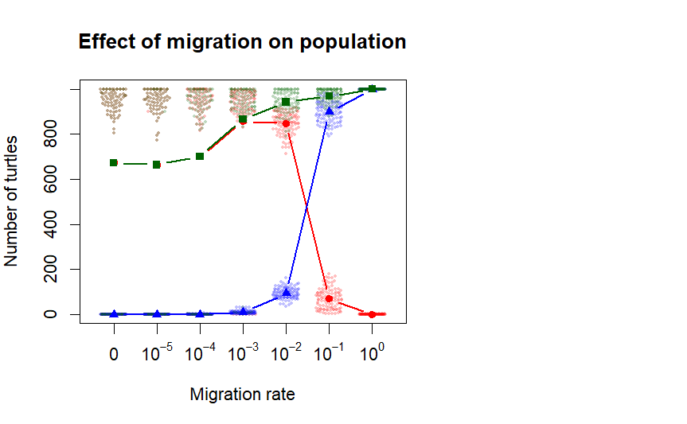

```r
legend(
  "topright",
  inset = c(-0,65, 0),cex = 0.6,
  legend = c("Adapted turtles (A)", "Migrating turtles (a)", "Total population (a + A)"),
  col = c("red", "blue", "darkgreen"),
  pch = c(19, 17, 15),
  lty = 1,
  lwd = 2,
  bty = "n",
  xpd = NA
)

# Restore the standard plotting margins, leave space on the right for the legend, if needed.
par(mar = c(5, 4, 4, 2), xpd = FALSE)
```

# Total population size and frequencies

```r
# Calculate Frequencies
# Calculate the total local population at each generation
N_total <- output[, "a"] + output[, "A"]

# Calculate the frequency of type a
freq_a <- ifelse(
  N_total > 0,
  output[, "a"] / N_total,
  NA
)

# Calculate the frequency of type A
freq_A <- ifelse(
  N_total > 0,
  output[, "A"] / N_total,
  NA
)

# Store the results in a data frame
frequency_output <- data.frame(
  Generations = 0:(nrow(output) - 1),
  N_total = N_total,
  freq_a = freq_a,
  freq_A = freq_A
)

# Display the frequency results
print(frequency_output)
```

```
    Generations N_total freq_a freq_A
0             0       0     NA     NA
1             1       0     NA     NA
2             2       0     NA     NA
3             3       0     NA     NA
4             4       0     NA     NA
5             5       0     NA     NA
6             6       0     NA     NA
7             7       0     NA     NA
8             8       0     NA     NA
9             9       0     NA     NA
10           10       0     NA     NA
11           11       0     NA     NA
12           12       0     NA     NA
13           13       0     NA     NA
```

[output cut: 237 more lines]